# Feature selection: escolhendo as variáveis para o modelo

## Orientacoes para execucao

Todos os pacotes utilizados neste script devem ser/estar instalados no seu ambiente de desenvolvimento. Para instalar um pacote use o comando install.packages(“nome_do_pacote”)

## Carrega os pacotes

```r
library(mlbench)
library(caret)
library(corrplot)
library(Boruta)
library(randomForest)
```

## Garante a reproducividade do código

```r
set.seed(123)
```

## Carrega os dados que serão utilizados

```r
data(PimaIndiansDiabetes)
```

## Encontrar variáveis correlacionadas (Filter Method)

Variáveis altamente correlacionadas podem prejudicar nosso modelo. Nesta primeira parte vamos encontrar estas variáveis e removê-las do dataset de treino. Atenção: Não necessariamente variáveis correlacionadas reduzem a acuracidade do modelo. Faça os testes necessários sem e com estes atributos.

Calcula a matriz de correlação entre as variáveis independentes.

```r
correlationMatrix <- cor(PimaIndiansDiabetes[,1:8])
```

Exibe a matrix.

```r
print(correlationMatrix)
```

```
##             pregnant    glucose   pressure     triceps     insulin
## pregnant  1.00000000 0.12945867 0.14128198 -0.08167177 -0.07353461
## glucose   0.12945867 1.00000000 0.15258959  0.05732789  0.33135711
## pressure  0.14128198 0.15258959 1.00000000  0.20737054  0.08893338
## triceps  -0.08167177 0.05732789 0.20737054  1.00000000  0.43678257
## insulin  -0.07353461 0.33135711 0.08893338  0.43678257  1.00000000
## mass      0.01768309 0.22107107 0.28180529  0.39257320  0.19785906
## pedigree -0.03352267 0.13733730 0.04126495  0.18392757  0.18507093
## age       0.54434123 0.26351432 0.23952795 -0.11397026 -0.04216295
##                mass    pedigree         age
## pregnant 0.01768309 -0.03352267  0.54434123
## glucose  0.22107107  0.13733730  0.26351432
## pressure 0.28180529  0.04126495  0.23952795
## triceps  0.39257320  0.18392757 -0.11397026
## insulin  0.19785906  0.18507093 -0.04216295
## mass     1.00000000  0.14064695  0.03624187
## pedigree 0.14064695  1.00000000  0.03356131
## age      0.03624187  0.03356131  1.00000000
```

Mostra a correlação por meio de um gráfico.

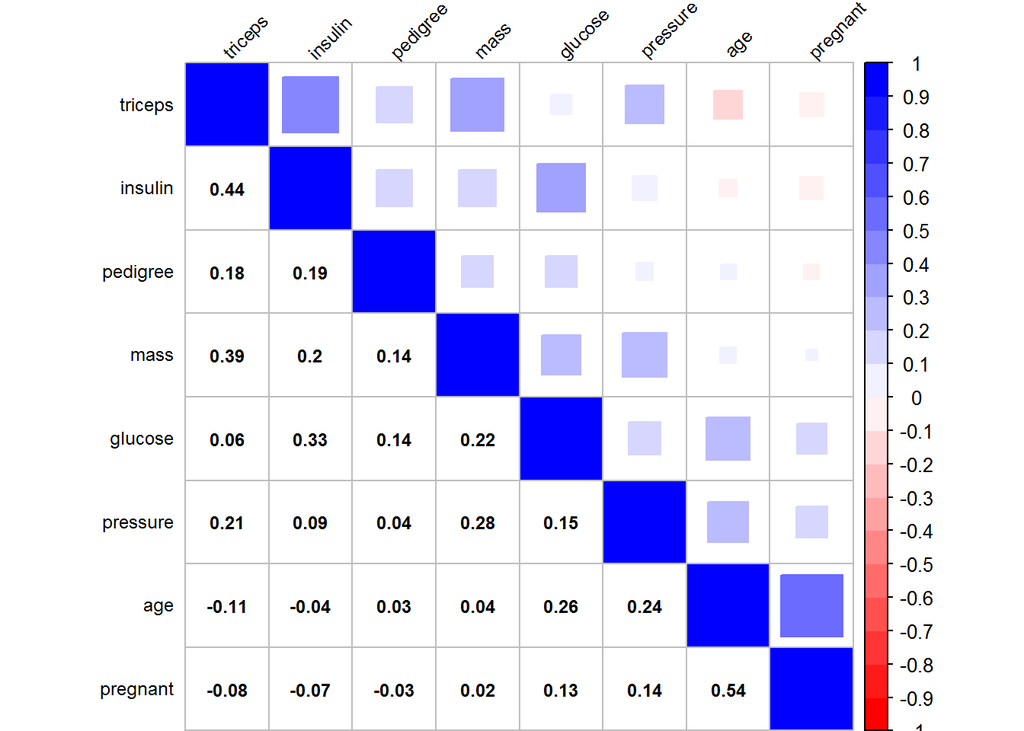

```r
col3 <- colorRampPalette(c("red", "white", "blue"))
corrplot(correlationMatrix, order="AOE", method="square", col=col3(20), tl.srt=45, tl.cex=0.75, tl.col="black") #tl.pos="d"
corrplot(correlationMatrix, add=TRUE, type="lower", method="number", order="AOE", col="black", diag=FALSE, tl.pos="n", cl.pos="n", number.cex=0.75)
```

Encontra os atributos altamente correlacionados (vamos usar aqui r > 0.7).

```r
highlyCorrelated <- findCorrelation(correlationMatrix, cutoff=0.7)
```

Mostra os índices das colunas altamente correlacionadas.

```r
print(highlyCorrelated)
```

```
## integer(0)
```

Retire estas colunas do seu dataset.

```r
PimaIndiansDiabetesTratado <- PimaIndiansDiabetes[,-highlyCorrelated]
```

## Identificando atributos com valores constantes

Atributos com valores constantes não são importantes para o modelo.

Criando um atributo com valor constante para fazermos o teste.

```r
PimaIndiansDiabetes2 <- cbind(PimaIndiansDiabetes, atributo_constante = 1)
```

Elimina os valores constantes.

```r
i<-0
for (f in names(PimaIndiansDiabetes2)) {
  if (length(unique(PimaIndiansDiabetes2[[f]])) == 1) {
    cat(f, "é uma variável constante no dataset de treino.\n")
    PimaIndiansDiabetes2[[f]] <- NULL
    i <- i + 1
  }
}
```

```
## atributo_constante é uma variável constante no dataset de treino.
```

```r
cat("Total de variáveis excluídas: ", i)
```

```
## Total de variáveis excluídas:  1
```

## Identificando variáveis idênticas (possuem a mesma informação)

Atributos com valores idênticos têm o mesmo peso no modelo. Nestes casos podemos usar apenas um deles.

Criando dois atributos com valores idênticos para fazermos o teste.

```r
PimaIndiansDiabetes2 <- cbind(PimaIndiansDiabetes, atributo_identico1 = 1)
PimaIndiansDiabetes2 <- cbind(PimaIndiansDiabetes2, atributo_identico2 = 1)
head(PimaIndiansDiabetes2)
```

```
##   pregnant glucose pressure triceps insulin mass pedigree age diabetes
## 1        6     148       72      35       0 33.6    0.627  50      pos
## 2        1      85       66      29       0 26.6    0.351  31      neg
## 3        8     183       64       0       0 23.3    0.672  32      pos
## 4        1      89       66      23      94 28.1    0.167  21      neg
## 5        0     137       40      35     168 43.1    2.288  33      pos
## 6        5     116       74       0       0 25.6    0.201  30      neg
##   atributo_identico1 atributo_identico2
## 1                  1                  1
## 2                  1                  1
## 3                  1                  1
## 4                  1                  1
## 5                  1                  1
## 6                  1                  1
```

Remove os atributos idênticos.

```r
# Encontra os atributos que devem ser removidos e grava os nomes na variável "toRemove"
featuresPair <- combn(names(PimaIndiansDiabetes2), 2, simplify = F)
toRemove <- c()
for(pair in featuresPair) {
  f1 <- pair[1]
  f2 <- pair[2]

  if (!(f1 %in% toRemove) & !(f2 %in% toRemove)) {
    if (all(PimaIndiansDiabetes2[[f1]] == PimaIndiansDiabetes2[[f2]])) {
      cat(f1, "e", f2, "são iguais.\n")
      toRemove <- c(toRemove, f2)
    }
  }
}
```

```
## atributo_identico1 e atributo_identico2 são iguais.
```

```r
# Seleciona as colunas que devem ficar no dataset final
feature.names <- setdiff(names(PimaIndiansDiabetes2), toRemove)

#ajusta dataset
PimaIndiansDiabetes2 <- PimaIndiansDiabetes2[, feature.names]

head(PimaIndiansDiabetes2)
```

```
##   pregnant glucose pressure triceps insulin mass pedigree age diabetes
## 1        6     148       72      35       0 33.6    0.627  50      pos
## 2        1      85       66      29       0 26.6    0.351  31      neg
## 3        8     183       64       0       0 23.3    0.672  32      pos
## 4        1      89       66      23      94 28.1    0.167  21      neg
## 5        0     137       40      35     168 43.1    2.288  33      pos
## 6        5     116       74       0       0 25.6    0.201  30      neg
##   atributo_identico1
## 1                  1
## 2                  1
## 3                  1
## 4                  1
## 5                  1
## 6                  1
```

## Recursive Feature Elimination - RFE (wrapper method)

Este é um método mais robusto onde são avaliados os impactos das variáveis combinadas. Primeiramente, treina-se um modelo com todas as variáveis e avalia-se seu desempenho em um conjunto de dados apartado. Em seguida, retira-se “x”% das variáveis mais fracas e treina-se novamente o modelo com as variáveis restantes. O processo continua até se observar que não é mais possível melhorar a acuracidade do modelo.

Define os parâmetros de controle do RFE usando uma função de seleção random forest (mesma usada no algoritmo Boruta, mais a frente)

```r
control <- rfeControl(functions=rfFuncs, method="cv", number=10)
```

Executa o RFE.

```r
results <- rfe(PimaIndiansDiabetes[,1:8], PimaIndiansDiabetes[,9], sizes=c(1:8), rfeControl=control)
```

Resultados.

```r
print(results)
```

```
##
## Recursive feature selection
##
## Outer resampling method: Cross-Validated (10 fold)
##
## Resampling performance over subset size:
##
##  Variables Accuracy  Kappa AccuracySD KappaSD Selected
##          1   0.6978 0.2731    0.04720  0.1337
##          2   0.7174 0.3519    0.07412  0.1695
##          3   0.7291 0.3849    0.04715  0.1089
##          4   0.7396 0.4084    0.06561  0.1649
##          5   0.7396 0.4083    0.04346  0.1101
##          6   0.7487 0.4291    0.05112  0.1298
##          7   0.7565 0.4487    0.04840  0.1128
##          8   0.7669 0.4722    0.04754  0.1149        *
##
## The top 5 variables (out of 8):
##    glucose, mass, age, pregnant, pedigree
```

Lista as variáveis escolhidas.

```r
predictors(results)
```

```
## [1] "glucose"  "mass"     "age"      "pregnant" "pedigree" "insulin"
## [7] "triceps"  "pressure"
```

Plota os resultados em um gráfico.

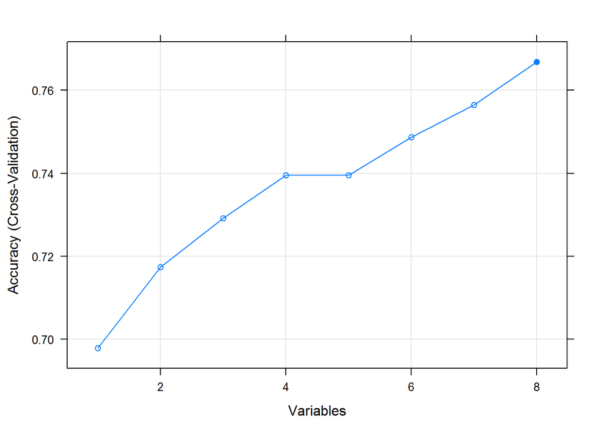

```r
plot(results, type=c("g", "o"))
```

## Boruta algorithm (wrapper method)

Executa o algoritmo Boruta.

```r
boruta.train <- Boruta(diabetes~., data = PimaIndiansDiabetes, doTrace = 2)
print(boruta.train)
```

```
## Boruta performed 99 iterations in 12.87739 secs.
##  7 attributes confirmed important: age, glucose, insulin, mass,
## pedigree and 2 more;
##  No attributes deemed unimportant.
##  1 tentative attributes left: pressure;
```

Plota os resultados.

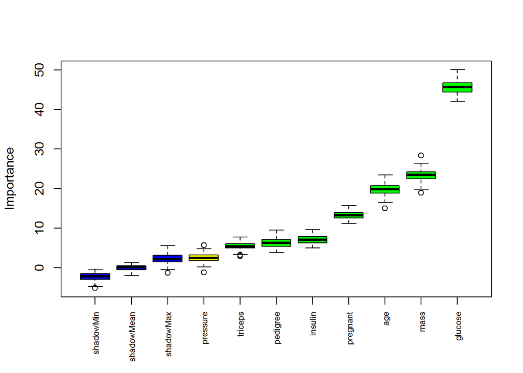

```r
plot(boruta.train, xlab = "", xaxt = "n")
lz<-lapply(1:ncol(boruta.train$ImpHistory),function(i)boruta.train$ImpHistory[is.finite(boruta.train$ImpHistory[,i]),i])
names(lz) <- colnames(boruta.train$ImpHistory)
Labels <- sort(sapply(lz,median))
axis(side = 1,las=2,labels = names(Labels),at = 1:ncol(boruta.train$ImpHistory), cex.axis = 0.7)
```

Classifica os atributos entre “confirmado” ou “rejeitado”

```r
final.boruta <- TentativeRoughFix(boruta.train)
print(final.boruta)
```

```
## Boruta performed 99 iterations in 12.87739 secs.
## Tentatives roughfixed over the last 99 iterations.
##  7 attributes confirmed important: age, glucose, insulin, mass,
## pedigree and 2 more;
##  1 attributes confirmed unimportant: pressure;
```

Lista os atributos selecionados.

```r
getSelectedAttributes(final.boruta, withTentative = F)
```

```
## [1] "pregnant" "glucose"  "triceps"  "insulin"  "mass"     "pedigree"
## [7] "age"
```

```r
boruta.df <- attStats(final.boruta)
print(boruta.df)
```

```
##            meanImp medianImp    minImp    maxImp  normHits  decision
## pregnant 13.280364 13.232065 11.163660 15.665906 1.0000000 Confirmed
## glucose  45.675959 45.650593 42.052641 50.030650 1.0000000 Confirmed
## pressure  2.490379  2.490660 -1.214269  5.728168 0.5454545  Rejected
## triceps   5.436439  5.409703  2.908774  7.723689 0.9797980 Confirmed
## insulin   7.060734  7.061989  4.965804  9.637114 0.9898990 Confirmed
## mass     23.388765 23.450919 18.902143 28.380400 1.0000000 Confirmed
## pedigree  6.401514  6.320704  3.793473  9.483110 1.0000000 Confirmed
## age      19.881075 19.845165 15.067325 23.417828 1.0000000 Confirmed
```

> Também existe um outro conhecido wrapper method chamado Genetic Algorithm - GA Você encontrará exemplos em: https://www.r-bloggers.com/feature-selection-with-carets-genetic-algorithm-option/

Referências:

Adaptei este material do livro Machine Learning Mastery in R, de Jason Brownlee Para os que buscam proficiência em Machine Learning, considero uma leitura obrigatória.

Exemplo de uso do Boruta foi retirado de https://www.analyticsvidhya.com, by Debarati Dutta

Identificação de valores constantes e idênticos retirados de competições do Kaggle